# pm2.5 eda

2023-11-13

EDA done based on questions for Course Project 2 for Exploratory Data Analysis course by John Hopkins University

## Loading data

```r
dt <- fread("data/merged.csv") # run prep_data to create this file
```

Data consists of a summary data frame and a codetable data frame, which have been merged into merged.csv. Summary contains all of the PM2.5 commissions data for 1999, 2002, 2005, 2008. The code table provides a mapping from the SCC digit strings in the summary table to the actual name of the PM2.5 source.

```r
summary(dt)
```

```
##      SCC                fips            Pollutant           Emissions
##  Length:6497651     Length:6497651     Length:6497651     Min.   :     0.0
##  Class :character   Class :character   Class :character   1st Qu.:     0.0
##  Mode  :character   Mode  :character   Mode  :character   Median :     0.0
##                                                           Mean   :     3.4
##                                                           3rd Qu.:     0.1
##                                                           Max.   :646952.0
##      type                year       Short.Name         EI.Sector
##  Length:6497651     Min.   :1999   Length:6497651     Length:6497651
##  Class :character   1st Qu.:2002   Class :character   Class :character
##  Mode  :character   Median :2005   Mode  :character   Mode  :character
##                     Mean   :2004
##                     3rd Qu.:2008
##                     Max.   :2008
```

```r
str(dt)
```

```
## Classes 'data.table' and 'data.frame':   6497651 obs. of  8 variables:
##  $ SCC       : chr  "10100101" "10100101" "10100101" "10100101" ...
##  $ fips      : chr  "34017" "01123" "08041" "42109" ...
##  $ Pollutant : chr  "PM25-PRI" "PM25-PRI" "PM25-PRI" "PM25-PRI" ...
##  $ Emissions : num  898.42 0.08 2.48 58.61 131.8 ...
##  $ type      : chr  "POINT" "POINT" "POINT" "POINT" ...
##  $ year      : int  1999 2002 1999 2002 2005 1999 2005 2005 2008 1999 ...
##  $ Short.Name: chr  "Ext Comb /Electric Gen /Anthracite Coal /Pulverized Coal" "Ext Comb /Electric Gen /Anthracite Coal /Pulverized Coal" "Ext Comb /Electric Gen /Anthracite Coal /Pulverized Coal" "Ext Comb /Electric Gen /Anthracite Coal /Pulverized Coal" ...
##  $ EI.Sector : chr  "Fuel Comb - Electric Generation - Coal" "Fuel Comb - Electric Generation - Coal" "Fuel Comb - Electric Generation - Coal" "Fuel Comb - Electric Generation - Coal" ...
##  - attr(*, ".internal.selfref")=<externalptr>
```

```r
slice_sample(dt, n=5)
```

```
##           SCC  fips Pollutant    Emissions     type year
## 1: 223007417X 32021  PM25-PRI 5.000000e-02  ON-ROAD 2002
## 2: 220102017B 37035  PM25-PRI 1.500000e-01  ON-ROAD 2002
## 3: 223007317T 54083  PM25-PRI 5.680315e-04  ON-ROAD 2002
## 4: 220107013X 20009  PM25-PRI 1.400000e-01  ON-ROAD 2002
## 5: 2610030000 13283  PM25-PRI 1.191600e+01 NONPOINT 2008
##                                                                                                     Short.Name
## 1:                     Highway Veh - Diesel - Heavy Duty (HDDV) Class 8A & 8B - Rural Major Collector: Exhaust
## 2:                        Highway Veh - Gasoline - Light Duty Trucks 1 & 2 - Rural Major Collector: Brake Wear
## 3:                     Highway Veh - Diesel - Heavy Duty (HDDV) Class 6 & 7 - Rural Major Collector: Tire Wear
## 4: Highway Veh - Gasoline - Heavy Duty Veh 2B thru 8B & Buses (HDGV) - Rural Other Principal Arterial: Exhaust
## 5:                              Open Burning /Residential /Household Waste (use 26-10-000-xxx for Yard Wastes)
##                                        EI.Sector
## 1:   Mobile - On-Road Diesel Heavy Duty Vehicles
## 2: Mobile - On-Road Gasoline Light Duty Vehicles
## 3:   Mobile - On-Road Diesel Heavy Duty Vehicles
## 4: Mobile - On-Road Gasoline Heavy Duty Vehicles
## 5:                                Waste Disposal
```

## Question 1: Have total emissions from PM2.5 decreased from 1999 to 2008?

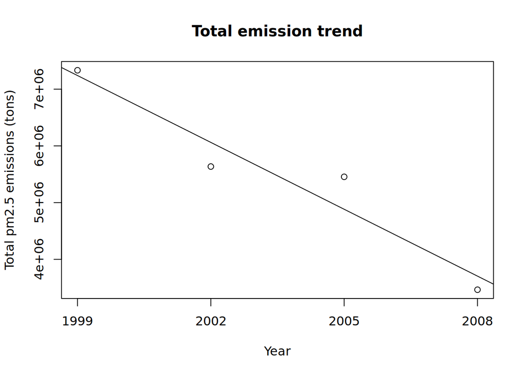

This plot shows a clear negative trend, meaning that emissions have decreased from 1999 to 2008.

## Question 2: Have total emissions from PM2.5 decreased in Baltimore City, Maryland

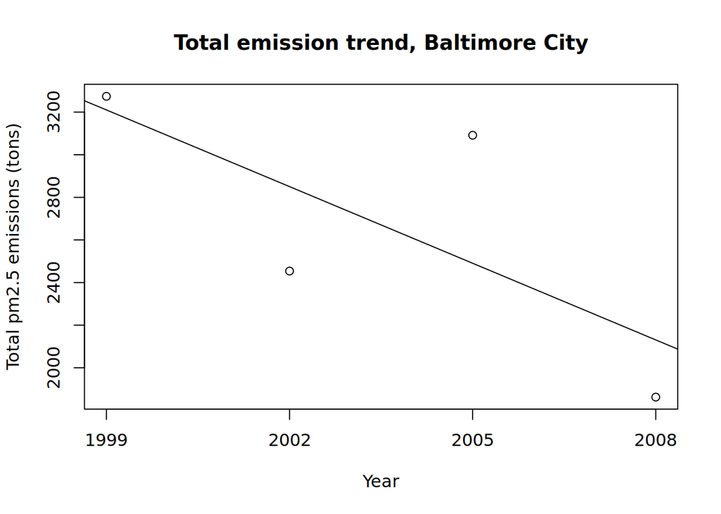

## Question 3: Of the 4 types of sources, which see decreases in emissions for Baltimore City

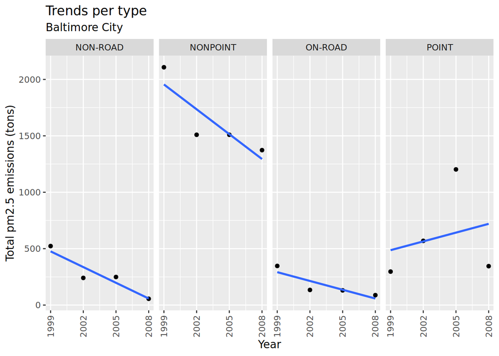

From this plot we can see taht the pm2.5 trends downwards for NON-ROAD, NON-POINT, and ROAD. But it is trending up for the POINT type.

## Question 4: How have emissions from coal combustion sources changed?

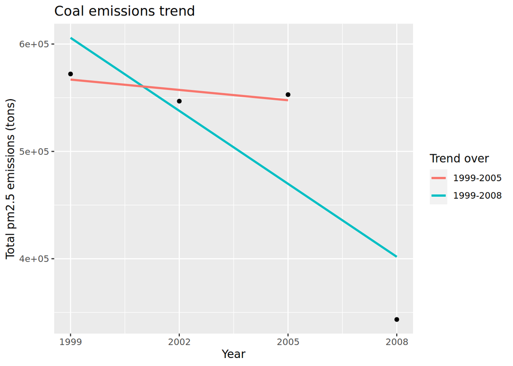

Yes! Although the trend for 1999-2005 (shown in red) seems to be fairly consistent, the only real decrease being 2008.

## Question 5: How have emissions from motor vehicle sources changed?

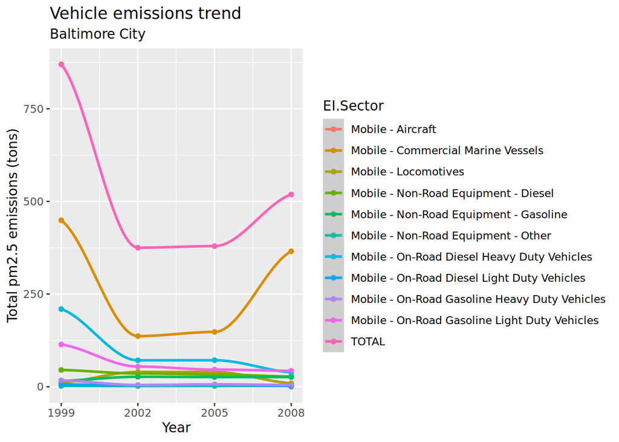

Overall emissions from vehicles are lower than in 1999, but have risen in 2008 mainly due to commercial marine vessels, which is the main contributor.

## Question 6: Has Baltimore City emissions from motor vehicles changed greater than in Los Angeles County?

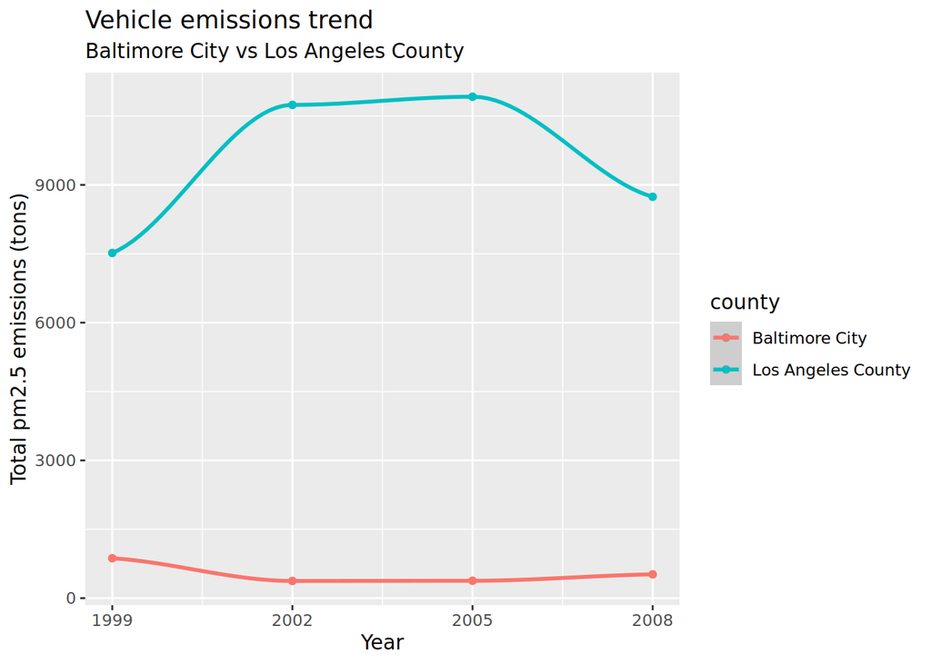

The change in Los Angeles County is much greater, presumably due to the significant population difference (9.78 million vs 560 thousand as of 2008).